# R Project 1: Analysis of Olympic Games data

Oxana Kolpakova

06 11 2021

For many years, the Olympic Games have been held all over the world, and participants from all over the world compete for success in various sports. In this project, we will correct the incoming data, analyze it according to several required parameters and make EDA

Specifying the working directory.

```r
#setwd("C:/Users/1/Desktop/olimpic_games_folder")
```

Load the necessary libraries.

```r
library(plyr)
library(dplyr)
library(ggplot2)
library(GenomicRanges)
library(doBy)
library(tidyverse)
library(foreign)
library(cowplot)
```

Removing workspace stuff.

```r
rm(list = ls())
```

1. Import data sets. We merged all *.csv files into one table

```r
Olimpic_Games <- rbind(ldply(list.files(path = "C:/Users/1/Desktop/olimpic_games_folder/data_folder/raw_data", pattern = "*.csv", full.names=TRUE), read.csv))
```

Look at our data

```r
str(Olimpic_Games)
```

```
## 'data.frame':    271115 obs. of  15 variables:
##  $ ID    : int  1 2 3 4 5 5 5 5 5 5 ...
##  $ Name  : chr  "A Dijiang" "A Lamusi" "Gunnar Nielsen Aaby" "Edgar Lindenau Aabye" ...
##  $ Sex   : chr  "M" "M" "M" "M" ...
##  $ Age   : int  24 23 24 34 21 21 25 25 27 27 ...
##  $ Height: int  180 170 NA NA 185 185 185 185 185 185 ...
##  $ Weight: num  80 60 NA NA 82 82 82 82 82 82 ...
##  $ Team  : chr  "China" "China" "Denmark" "Denmark/Sweden" ...
##  $ NOC   : chr  "CHN" "CHN" "DEN" "DEN" ...
##  $ Games : chr  "1992 Summer" "2012 Summer" "1920 Summer" "1900 Summer" ...
##  $ Year  : int  1992 2012 1920 1900 1988 1988 1992 1992 1994 1994 ...
##  $ Season: chr  "Summer" "Summer" "Summer" "Summer" ...
##  $ City  : chr  "Barcelona" "London" "Antwerpen" "Paris" ...
##  $ Sport : chr  "Basketball" "Judo" "Football" "Tug-Of-War" ...
##  $ Event : chr  "Basketball Men's Basketball" "Judo Men's Extra-Lightweight" "Football Men's Football" "Tug-Of-War Men's Tug-Of-War" ...
##  $ Medal : chr  NA NA NA "Gold" ...
```

This is a historical on the modern Olympic Games, including all the Games from Athens 1896 to Rio 2016. The athlete events dataset contains information about Olympic Athletes and events that they have competed in, including biological data (Age, Sex, Height, Weight etc.) and event data (Year, Season, City, Sport etc.). The NOC (National Organizing Committee) regions dataset possesses information about the countries that compete in the Olympics, including the country name and any notes about said country.

The file athlete_events.csv contains 271115 rows and 15 columns. Each row corresponds to an individual athlete competing in an individual Olympic event.

The Athletes dataset contains 15 variables:

ID: A number used as a unique identifier for each athlete  
Name: The athlete’s name(s) in the form of First Middle Last where available  
Sex: The athlete’s gender; one of M or F Age: The athlete’s age in years  
Height: The athlete’s height in centimeters (cm)  
Weight: The athlete’s weight in kilograms (kg)  
Team: The name of the team that the athlete competed for  
NOC: The National Organizing Committee’s 3-letter code  
Games: The year and season of the Olympics the athlete competed in in the format YYYY Season  
Year: The year of the Olympics that the athlete competed in  
Season: The season of the Olympics that the athlete competed in  
City: The city that hosted the Olympics that the athlete competed in  
Sport: The sport that the athlete competed in  
Event: The event that the athlete competed in  
Medal: The medal won by the athlete; one of Gold, Silver, or Bronze. NA if no medal was won.

2. Check whether there are missed or non-valid values.

```
Olimpic_Games[Olimpic_Games == ""] <- "NA"
# Sex
unique(Olimpic_Games[3]) #looking for unique
Olimpic_Games$Sex[Olimpic_Games$Sex == "G"] <- "NA" #correct the slip
Olimpic_Games$Sex <- factor(Olimpic_Games$Sex) #change data type to factor
# Age
unique(Olimpic_Games[4])
Olimpic_Games$Age[Olimpic_Games$Age == "240"] <- "NA" #remove outliers
Olimpic_Games$Age <- as.integer(Olimpic_Games$Age) # change data type to int
# Height
unique(Olimpic_Games[5])
Olimpic_Games$Height[Olimpic_Games$Height == "340"] <- "NA" #remove outliers
Olimpic_Games$Height <- as.integer(Olimpic_Games$Height) # change data type to int
# Weight
unique(Olimpic_Games[6])
Olimpic_Games$Weight[Olimpic_Games$Weight <= 20] <- "NA"#remove outliers
Olimpic_Games$Weight <- as.numeric(Olimpic_Games$Weight) # change data type to num
# NOC
unique(Olimpic_Games[8])
Olimpic_Games$NOC[Olimpic_Games$NOC == "JPN"] <- "JP" #correct the slip
Olimpic_Games$NOC <- factor(Olimpic_Games$NOC) #change data type to factor
# Games
unique(Olimpic_Games[9])
Olimpic_Games$Games[Olimpic_Games$Games == "2000 Su"] <- "2000 Summer"
Olimpic_Games$Games[Olimpic_Games$Games == "2004 Summe"] <- "2004 Summer" #correct the slip
# Season
unique(Olimpic_Games[11])
Olimpic_Games$Season <- factor(Olimpic_Games$Season) #change data type to factor
# City
unique(Olimpic_Games[12])
Olimpic_Games$City[Olimpic_Games$City == "Moskva"] <- "Moscow" #correct the slip
# Sport
unique(Olimpic_Games[13])
Olimpic_Games$Sport[Olimpic_Games$Sport == "Footba"] <- "Football" #correct the slip
# Event
unique(Olimpic_Games[14])
# Medal
unique(Olimpic_Games[15])
Olimpic_Games$Medal[Olimpic_Games$Medal == "<NA>"] <- "NA"
Olimpic_Games$Medal <- factor(Olimpic_Games$Medal) #change data type to factor
```

```r
write.csv(Olimpic_Games, 'C:/Users/1/Desktop/olimpic_games_folder/data_folder/processed_data/processed_data.csv', row.names = FALSE)
Olimpic_Games <- read.csv(file='C:/Users/1/Desktop/olimpic_games_folder/data_folder/processed_data/processed_data.csv',header=T, )
str(Olimpic_Games)
```

```
## 'data.frame':    271115 obs. of  15 variables:
##  $ ID    : int  1 2 3 4 5 5 5 5 5 5 ...
##  $ Name  : chr  "A Dijiang" "A Lamusi" "Gunnar Nielsen Aaby" "Edgar Lindenau Aabye" ...
##  $ Sex   : chr  "M" "M" "M" "M" ...
##  $ Age   : int  24 23 24 34 21 21 25 25 27 27 ...
##  $ Height: int  180 170 NA NA 185 185 185 185 185 185 ...
##  $ Weight: num  80 60 NA NA 82 82 82 82 82 82 ...
##  $ Team  : chr  "China" "China" "Denmark" "Denmark/Sweden" ...
##  $ NOC   : chr  "CHN" "CHN" "DEN" "DEN" ...
##  $ Games : chr  "1992 Summer" "2012 Summer" "1920 Summer" "1900 Summer" ...
##  $ Year  : int  1992 2012 1920 1900 1988 1988 1992 1992 1994 1994 ...
##  $ Season: chr  "Summer" "Summer" "Summer" "Summer" ...
##  $ City  : chr  "Barcelona" "London" "Antwerpen" "Paris" ...
##  $ Sport : chr  "Basketball" "Judo" "Football" "Tug-Of-War" ...
##  $ Event : chr  "Basketball Men's Basketball" "Judo Men's Extra-Lightweight" "Football Men's Football" "Tug-Of-War Men's Tug-Of-War" ...
##  $ Medal : chr  NA NA NA "Gold" ...
```

Some descriptive statistics.

```r
summary(Olimpic_Games)
```

```
##        ID             Name               Sex                 Age
##  Min.   :     1   Length:271115      Length:271115      Min.   : 10.00
##  1st Qu.: 34643   Class :character   Class :character   1st Qu.: 21.00
##  Median : 68205   Mode  :character   Mode  :character   Median : 24.00
##  Mean   : 68249                                         Mean   : 25.56
##  3rd Qu.:102097                                         3rd Qu.: 28.00
##  Max.   :135571                                         Max.   :240.00
##                                                         NA's   :9476
##      Height          Weight          Team               NOC
##  Min.   :127.0   Min.   :  7.0   Length:271115      Length:271115
##  1st Qu.:168.0   1st Qu.: 60.0   Class :character   Class :character
##  Median :175.0   Median : 70.0   Mode  :character   Mode  :character
##  Mean   :175.3   Mean   : 70.7
##  3rd Qu.:183.0   3rd Qu.: 79.0
##  Max.   :340.0   Max.   :214.0
##  NA's   :60172   NA's   :62876
##     Games                Year         Season              City
##  Length:271115      Min.   :1896   Length:271115      Length:271115
##  Class :character   1st Qu.:1960   Class :character   Class :character
##  Mode  :character   Median :1988   Mode  :character   Mode  :character
##                     Mean   :1978
##                     3rd Qu.:2002
##                     Max.   :2016
##                     NA's   :7
##     Sport              Event              Medal
##  Length:271115      Length:271115      Length:271115
##  Class :character   Class :character   Class :character
##  Mode  :character   Mode  :character   Mode  :character
##
##
##
##
```

We will answer the questions asked by the project.  
3. Age of youngest athletes of both genders at the 1992 Olympics.

```r
min(subset(Olimpic_Games, Year == 1992 & Sex == "M" )[,4], na.rm=T)
```

```
## [1] 11
```

```r
min(subset(Olimpic_Games, Year == 1992 & Sex == "F" )[,4], na.rm=T)
```

```
## [1] 12
```

4. Mean and standard deviation of type Height for athletes of every gender.

```r
mean(subset(Olimpic_Games, Sex == "M")[,5], na.rm = T)
```

```
## [1] 178.8586
```

```r
sd(subset(Olimpic_Games, Sex == "M")[,5], na.rm = T)
```

```
## [1] 9.360374
```

```r
mean(subset(Olimpic_Games, Sex == "F")[,5], na.rm = T)
```

```
## [1] 167.8422
```

```r
sd(subset(Olimpic_Games, Sex == "F")[,5], na.rm = T)
```

```
## [1] 8.803426
```

```r
round(mean(subset(Olimpic_Games, Year == 2000 & Sex == "F")[,5], na.rm = T), digits=1)
```

```
## [1] 169
```

6. What sport did the heaviest athlete participate in at the 2006 Olympics?

```r
Weight_max <- max(subset(Olimpic_Games, Year == 2006)[,6], na.rm = T)
subset(Olimpic_Games, Year == 2006 & Weight == Weight_max)[,13]
```

```
## [1] "Skeleton"
```

```r
nrow(subset(Olimpic_Games, Year >= 1980 & Year <= 2010 & Medal == "Gold"))
```

```
## [1] 5743
```

8. How many times has athlete John Aalberg competed in the Olympics over the years?

```r
years<- unique(subset(Olimpic_Games, Name == "John Aalberg")[,10])
length(years)
```

```
## [1] 2
```

9. The least and most represented by the number of participants age groups of athletes at the 2008 Olympics. Possible age groups: [15-25), [25-35), [35-45), [45-55].

```r
cat1 <- nrow(subset(Olimpic_Games, Year == 2008 & Age >= 15 & Age < 25))
cat2 <- nrow(subset(Olimpic_Games, Year == 2008 & Age >= 25 & Age < 35))
cat3 <- nrow(subset(Olimpic_Games, Year == 2008 & Age >= 35 & Age < 45))
cat4 <- nrow(subset(Olimpic_Games, Year == 2008 & Age >= 45 & Age < 55))
which.min(c(cat1, cat2, cat3, cat4))
```

```
## [1] 4
```

```r
which.max(c(cat1, cat2, cat3, cat4))
```

```
## [1] 2
```

```r
nums1 <- length(unique(subset(Olimpic_Games, Year == 2008)[,13]))
nums2 <- length(unique(subset(Olimpic_Games, Year == 1994)[,13]))
abs(nums1 - nums2)
```

```
## [1] 22
```

11. 3 Top of countries for each type of medal for the Winter and Summer Olympic Games

```r
Only_gold_S <- subset(Olimpic_Games, Season == "Summer" & Medal == "Gold")
Only_silver_S <- subset(Olimpic_Games, Season == "Summer" & Medal == "Silver")
Only_bronze_S <- subset(Olimpic_Games, Season == "Summer" & Medal == "Bronze")
topG_S <- aggregate(Medal ~ NOC, data = Only_gold_S, FUN = length)
topS_S <- aggregate(Medal ~ NOC, data = Only_silver_S, FUN = length)
topB_S <- aggregate(Medal ~ NOC, data = Only_bronze_S, FUN = length)
# Top of Gold Medal for Summer
head(topG_S[with(topG_S, order(-Medal)), ], 3)[,1]
```

```
## [1] "USA" "URS" "GBR"
```

```r
# Top of Silver Medal for Summer
head(topS_S[with(topS_S, order(-Medal)), ], 3)[,1]
```

```
## [1] "USA" "GBR" "URS"
```

```r
# Top of Bronzal Medal for Summer
head(topB_S[with(topB_S, order(-Medal)), ], 3)[,1]
```

```
## [1] "USA" "GER" "GBR"
```

```r
Only_gold_W <- subset(Olimpic_Games, Season == "Winter" & Medal == "Gold")
Only_silver_W <- subset(Olimpic_Games, Season == "Winter" & Medal == "Silver")
Only_bronze_W <- subset(Olimpic_Games, Season == "Winter" & Medal == "Bronze")
topG_W <- aggregate(Medal ~ NOC, data = Only_gold_W, FUN = length)
topS_W <- aggregate(Medal ~ NOC, data = Only_silver_W, FUN = length)
topB_W <- aggregate(Medal ~ NOC, data = Only_bronze_W, FUN = length)
# Top of Gold Medal for Winter
head(topG_W[with(topG_W, order(-Medal)), ], 3)[,1]
```

```
## [1] "CAN" "URS" "USA"
```

```r
# Top of Silver Medal for Winter
head(topS_W[with(topS_W, order(-Medal)), ], 3)[,1]
```

```
## [1] "USA" "CAN" "NOR"
```

```r
# Top of Bronzal Medal for Winter
head(topB_W[with(topB_W, order(-Medal)), ], 3)[,1]
```

```
## [1] "FIN" "SWE" "USA"
```

12. Create a new variable Height_z_scores and store the values of the Height variable in it after it’s standardized.

```r
Height_z_scores <- (Olimpic_Games$Height - mean(Olimpic_Games$Height, na.rm = T))/sd(Olimpic_Games$Height, na.rm = T)
```

13. Create a new variable Height_min_max_scaled and store the values of the Height variable into it after applying min-max normalization to it.

```r
Height_min_max_scaled <- (Olimpic_Games$Height - min(Olimpic_Games$Height, na.rm = T)) / (max(Olimpic_Games$Height, na.rm = T) - min(Olimpic_Games$Height, na.rm = T))
```

14. Compare the height, weight and ages of men and women who competed in the Winter Olympics.

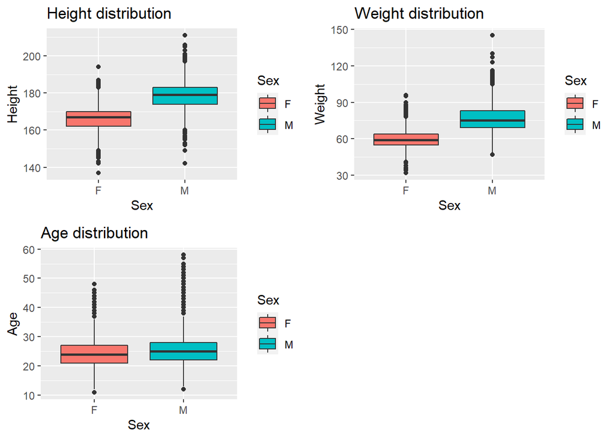

```r
library(cowplot)
OGW <- subset(Olimpic_Games, Season == "Winter")
OGW1 <- (ggplot(data = OGW, aes(x = Sex, y = Height, fill = Sex)) +
  geom_boxplot() +
  ggtitle("Height distribution "))
OGW2 <- (ggplot(data = OGW, aes(x = Sex, y = Weight, fill = Sex, )) +
  geom_boxplot()+
  ggtitle("Weight distribution "))
OGW3 <- ggplot(data = OGW, aes(x = Sex, y = Age, fill = Sex)) +
  geom_boxplot()+
  ggtitle("Age distribution ")
plot_grid(OGW1, OGW2, OGW3)
```

15. Whether there is a correlation between the variables Team and Medal?

```r
cor_Olimpic_Games <- Olimpic_Games
cor_Olimpic_Games$Medal <- factor(cor_Olimpic_Games$Medal, labels = c("1", "2", "3", "4"))
cor_Olimpic_Games$Medal <- as.numeric(cor_Olimpic_Games$Medal)
cor_Olimpic_Games$Team <- factor(cor_Olimpic_Games$Team)
cor_Olimpic_Games$Team <- as.numeric(cor_Olimpic_Games$Team)

T_M <- cor.test(cor_Olimpic_Games$Team, cor_Olimpic_Games$Medal, method="kendall")
T_M
```

```
##
##  Kendall's rank correlation tau
##
## data:  cor_Olimpic_Games$Team and cor_Olimpic_Games$Medal
## z = 3.3052, p-value = 0.0009491
## alternative hypothesis: true tau is not equal to 0
## sample estimates:
##        tau
## 0.01299047
```

The relationship between the number of medals and their types for each team is traced. Let’s take swimming, for example. These countries have more medals than other countries for political reasons. We choose the histogram because we want to clearly see the distribution of medals and also determine what type of medals the country won.

```r
swim <- Olimpic_Games %>%
  filter(Sport == "Swimming") %>%
  select(Name, Sex, Age, Team, NOC, Year, City, Event, Medal)

# Count Events, Nations, and Swimming competitions each year
counts_swim <- swim %>% filter(Team != "Unknown") %>%
  group_by(Year) %>%
  summarize(
    Events = length(unique(Event)),
    Nations = length(unique(Team)),
    Swimmings = length(unique(Name))
  )

swim <- Olimpic_Games %>%
  filter(Sport == "Swimming") %>%
  select(Name, Sex, Age, Team, NOC, Year, City, Event, Medal)

# Count Events, Nations, and Swimming competitions each year
counts_swim <- swim %>% filter(Team != "Unknown") %>%
  group_by(Year) %>%
  summarize(
    Events = length(unique(Event)),
    Nations = length(unique(Team)),
    Swimmings = length(unique(Name))
  )

# count number of medals awarded to each Team
medal_counts_swim <- swim %>% filter(!is.na(Medal))%>%
  group_by(Team, Medal) %>%
  summarize(Count=length(Medal))
```

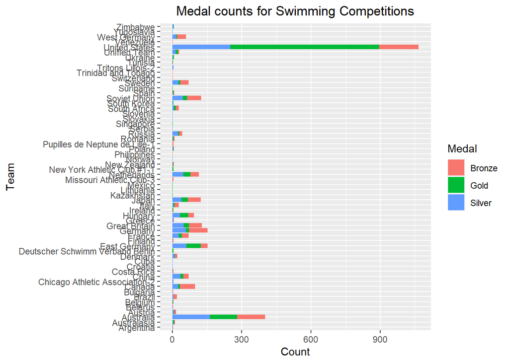

```r
#plot
ggplot(medal_counts_swim, aes(x=Team, y=Count, fill=Medal)) +
  geom_col() +
  coord_flip() +
  ggtitle("Medal counts for Swimming Competitions") +
  theme(plot.title = element_text(hjust = 0.5))
```

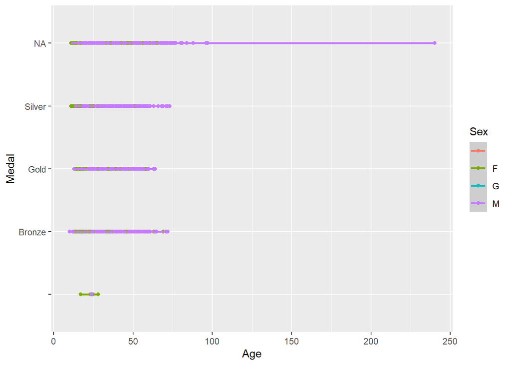

```r
#fit <- lm(Medal ~ Age + Sex, data = na.omit(Olimpic_Games))
#summary(fit)
ggplot(Olimpic_Games, aes(x = Age, y = Medal, col = Sex)) +
  geom_point()  +
  geom_smooth(method = 'lm')
```

[output not shown]